# Air Craft Accidents

Nicholas Norcia

November 27, 2018

This data comes from Kaggle.com. https://www.kaggle.com/saurograndi/airplane-crashes-since-1908 is the link to the overview of the dataset and examples of some work with it.

The data is of plane crashes from 1908 until 2017. The data consists of 5268 observations with 13 variables.

The date column needs to be changed in order to make it valuable for Rstudio.

```r
library(ggplot2); library(readr)

plane = read.csv("C:/Users/Mar/Desktop/2018/Data_Vis/Airplane_Crashes_and_Fatalities_Since_1908.csv", header = T)
```

```r
str(plane)
```

```
## 'data.frame':    5268 obs. of  13 variables:
##  $ Date        : Factor w/ 4753 levels "01/01/1966","01/01/1970",..: 3297 2372 2699 3184 3682 852 3099 2585 3387 3469 ...
##  $ Time        : Factor w/ 1006 levels "","00:00","00:01",..: 702 200 1 758 385 36 609 1 36 986 ...
##  $ Location    : Factor w/ 4304 levels "","1,200 miles off Dakar, AtlantiOcean",..: 848 123 4179 3388 2294 4059 3117 2288 284 3550 ...
##  $ Operator    : Factor w/ 2477 levels "","A B Aerotransport",..: 1567 1578 1825 1466 1466 1466 1466 1465 1466 1466 ...
##  $ Flight..    : Factor w/ 725 levels "","-","002","004",..: 1 1 2 1 1 1 1 1 1 1 ...
##  $ Route       : Factor w/ 3245 levels ""," - Tegucigalpa - Toncontin",..: 831 2982 1 1 1 1 1 1 1 1 ...
##  $ Type        : Factor w/ 2447 levels "","AÃ©rospatiale SE-210 Caravelle",..: 2419 1145 1032 2433 2435 2446 2434 2148 2439 2438 ...
##  $ Registration: Factor w/ 4906 levels ""," / ","01 / 02 / 03",..: 1 1 1 1 1 1 1 1 1 1 ...
##  $ cn.In       : Factor w/ 3708 levels ""," / 185-5547",..: 171 1 1 1 1 1 1 1 1 1 ...
##  $ Aboard      : int  2 5 1 20 30 41 19 20 22 19 ...
##  $ Fatalities  : int  1 5 1 14 30 21 19 20 22 19 ...
##  $ Ground      : int  0 0 0 0 0 0 0 0 0 0 ...
##  $ Summary     : Factor w/ 4674 levels "","31-7952246The pilot reported that he had a rough running engine and was making an emergency landing at Charlo A"| __truncated__,..: 1544 1676 3568 3213 1820 1189 1637 1203 2226 2266 ...
```

### Crashes per year, month, day

```r
library(dplyr); library(date)
```

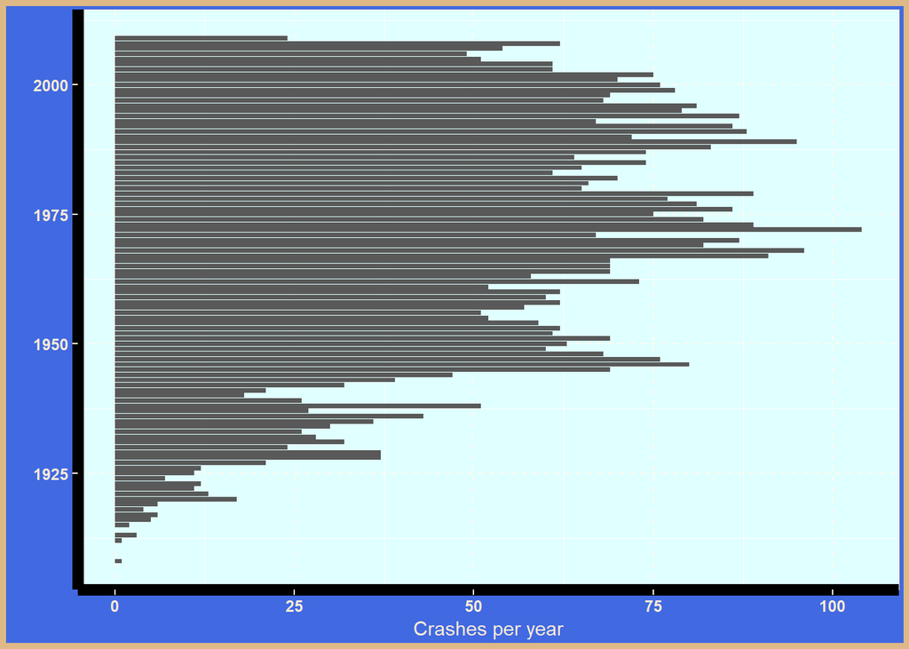

```r
plane$Date <- as.Date(plane$Date, "%m/%d/%Y")

plane$Year <- as.integer(format(plane$Date, "%Y"))
plane$Month <- format(plane$Date, "%m")
plane$Day <- as.integer(format(plane$Date, "%d"))

# plane.year <- plane['Year']
# plane.month <- plane['Month']
# plane.day <- plane['Day']

plane <- plane %>% mutate(year=factor(Year))
plane <- plane %>% mutate(month=factor(Month))
plane <- plane %>% mutate(day=factor(Day))

year_crashes <- ggplot(plane, aes(Year)) + geom_bar() + coord_flip() + xlab("") + ylab("Crashes per year")

month_crashes <- ggplot(plane, aes(Month)) + geom_bar() + coord_flip() + xlab("") + ylab("Crashes per month")
#
day_crashes <- ggplot(plane, aes(Day)) + geom_bar() + coord_flip() + xlab("") + ylab("Crashes per day")

year_crashes +
  theme(plot.background = element_rect(fill = "royalblue", color = "burlywood", size = 3)) +
  #theme(plot.background = element_rect(fill = "lightgoldenrod")) +
  theme(legend.background = element_rect(fill = "antiquewhite")) +
  theme(legend.position = "right", legend.direction = "vertical") +
  theme(axis.text = element_text(colour = "antiquewhite", face = "bold")) +
  theme(axis.title = element_text(colour = "antiquewhite")) +
  theme(axis.ticks = element_line(colour = "antiquewhite", size = .5)) +
  theme(panel.grid.major = element_line(colour = "floralwhite", linetype = "dashed")) +
  theme(panel.background = element_rect(fill = "lightcyan")) +
  theme(panel.border = element_rect(colour = "antiquewhite", fill = NA)) +
  theme(axis.line = element_line(size = 3, colour = "black")) +
  theme(legend.box.background = element_rect(colour = "floralwhite", size = 2))
```

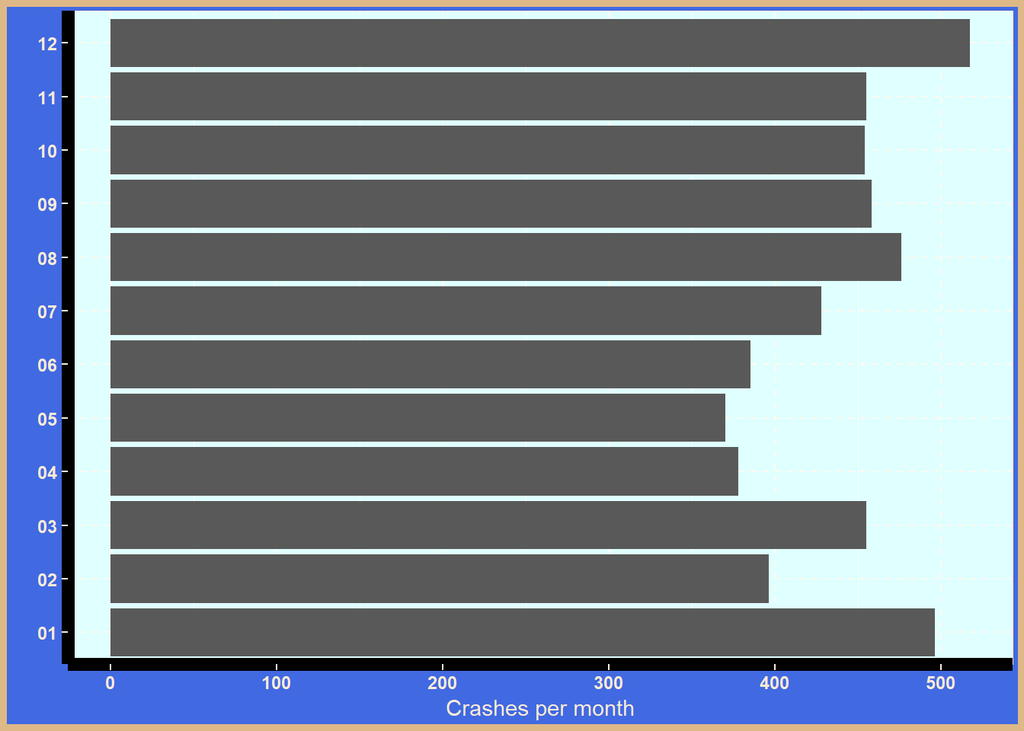

```r
month_crashes +
  theme(plot.background = element_rect(fill = "royalblue", color = "burlywood", size = 3)) +
  #theme(plot.background = element_rect(fill = "lightgoldenrod")) +
  theme(legend.background = element_rect(fill = "antiquewhite")) +
  theme(legend.position = "right", legend.direction = "vertical") +
  theme(axis.text = element_text(colour = "antiquewhite", face = "bold")) +
  theme(axis.title = element_text(colour = "antiquewhite")) +
  theme(axis.ticks = element_line(colour = "antiquewhite", size = .5)) +
  theme(panel.grid.major = element_line(colour = "floralwhite", linetype = "dashed")) +
  theme(panel.background = element_rect(fill = "lightcyan")) +
  theme(panel.border = element_rect(colour = "antiquewhite", fill = NA)) +
  theme(axis.line = element_line(size = 3, colour = "black")) +
  theme(legend.box.background = element_rect(colour = "floralwhite", size = 2))
```

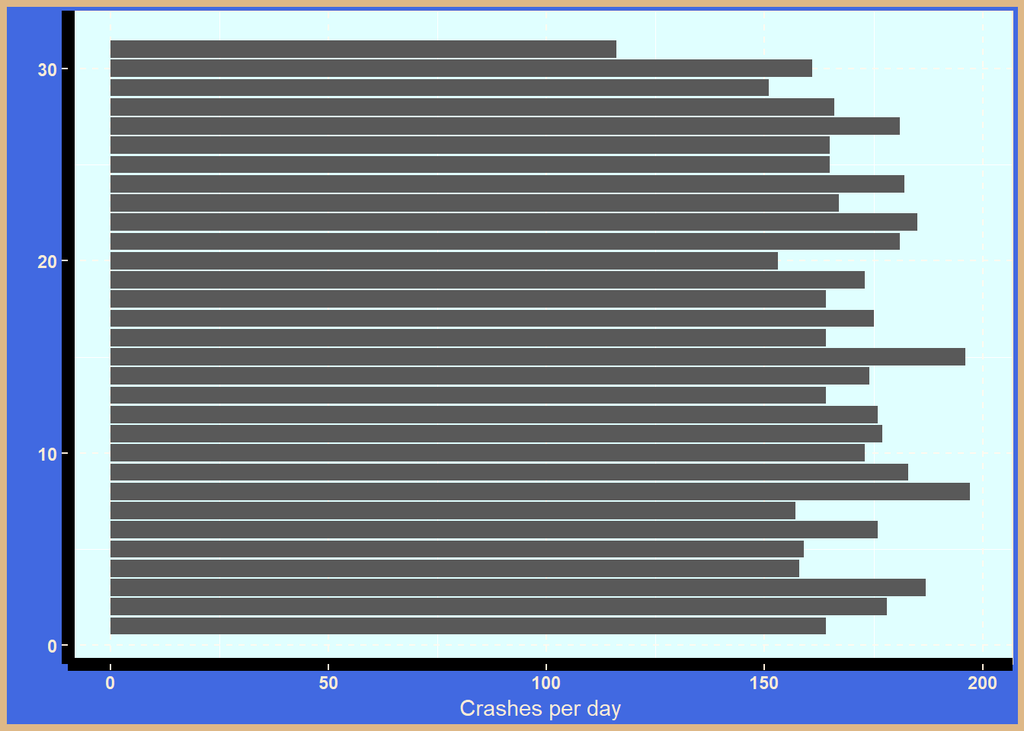

```r
day_crashes +
  theme(plot.background = element_rect(fill = "royalblue", color = "burlywood", size = 3)) +
  #theme(plot.background = element_rect(fill = "lightgoldenrod")) +
  theme(legend.background = element_rect(fill = "antiquewhite")) +
  theme(legend.position = "right", legend.direction = "vertical") +
  theme(axis.text = element_text(colour = "antiquewhite", face = "bold")) +
  theme(axis.title = element_text(colour = "antiquewhite")) +
  theme(axis.ticks = element_line(colour = "antiquewhite", size = .5)) +
  theme(panel.grid.major = element_line(colour = "floralwhite", linetype = "dashed")) +
  theme(panel.background = element_rect(fill = "lightcyan")) +
  theme(panel.border = element_rect(colour = "antiquewhite", fill = NA)) +
  theme(axis.line = element_line(size = 3, colour = "black")) +
  theme(legend.box.background = element_rect(colour = "floralwhite", size = 2))
```

These graphs show the amount of crashes per year, month, and day.

Crashes per year: shows us that since 2000 airplane crashes have been on a decline.

Crashes per month: There seems to be alot of crashes towards the beginning and end of the year. Perhaps the climate plays a factor.

Crashes per day: Not too much to see here. 31st has less crashes, but alot of months do not have 31 days.

### Number of Fatalities

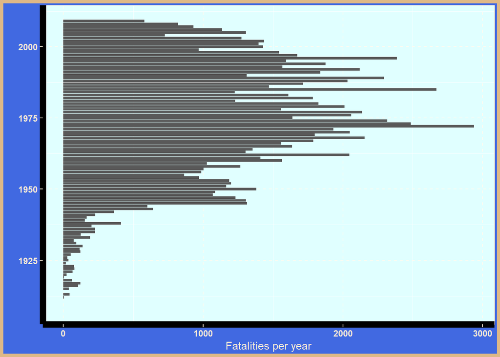

```r
fat_year <- ggplot(plane, aes(Year)) + geom_bar(aes(weight=Fatalities)) + coord_flip() + xlab("") + ylab("Fatalities per year")

fat_year +
  theme(plot.background = element_rect(fill = "royalblue", color = "burlywood", size = 3)) +
  #theme(plot.background = element_rect(fill = "lightgoldenrod")) +
  theme(legend.background = element_rect(fill = "antiquewhite")) +
  theme(legend.position = "right", legend.direction = "vertical") +
  theme(axis.text = element_text(colour = "antiquewhite", face = "bold")) +
  theme(axis.title = element_text(colour = "antiquewhite")) +
  theme(axis.ticks = element_line(colour = "antiquewhite", size = .5)) +
  theme(panel.grid.major = element_line(colour = "floralwhite", linetype = "dashed")) +
  theme(panel.background = element_rect(fill = "lightcyan")) +
  theme(panel.border = element_rect(colour = "antiquewhite", fill = NA)) +
  theme(axis.line = element_line(size = 3, colour = "black")) +
  theme(legend.box.background = element_rect(colour = "floralwhite", size = 2))
```

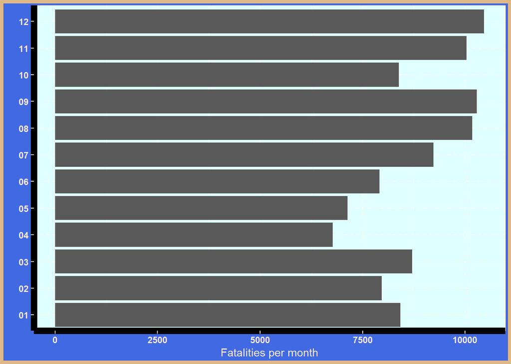

```r
fat_month <- ggplot(plane, aes(Month)) + geom_bar(aes(weight=Fatalities)) + coord_flip() + xlab("") + ylab("Fatalities per month")
fat_month +
  theme(plot.background = element_rect(fill = "royalblue", color = "burlywood", size = 3)) +
  #theme(plot.background = element_rect(fill = "lightgoldenrod")) +
  theme(legend.background = element_rect(fill = "antiquewhite")) +
  theme(legend.position = "right", legend.direction = "vertical") +
  theme(axis.text = element_text(colour = "antiquewhite", face = "bold")) +
  theme(axis.title = element_text(colour = "antiquewhite")) +
  theme(axis.ticks = element_line(colour = "antiquewhite", size = .5)) +
  theme(panel.grid.major = element_line(colour = "floralwhite", linetype = "dashed")) +
  theme(panel.background = element_rect(fill = "lightcyan")) +
  theme(panel.border = element_rect(colour = "antiquewhite", fill = NA)) +
  theme(axis.line = element_line(size = 3, colour = "black")) +
  theme(legend.box.background = element_rect(colour = "floralwhite", size = 2))
```

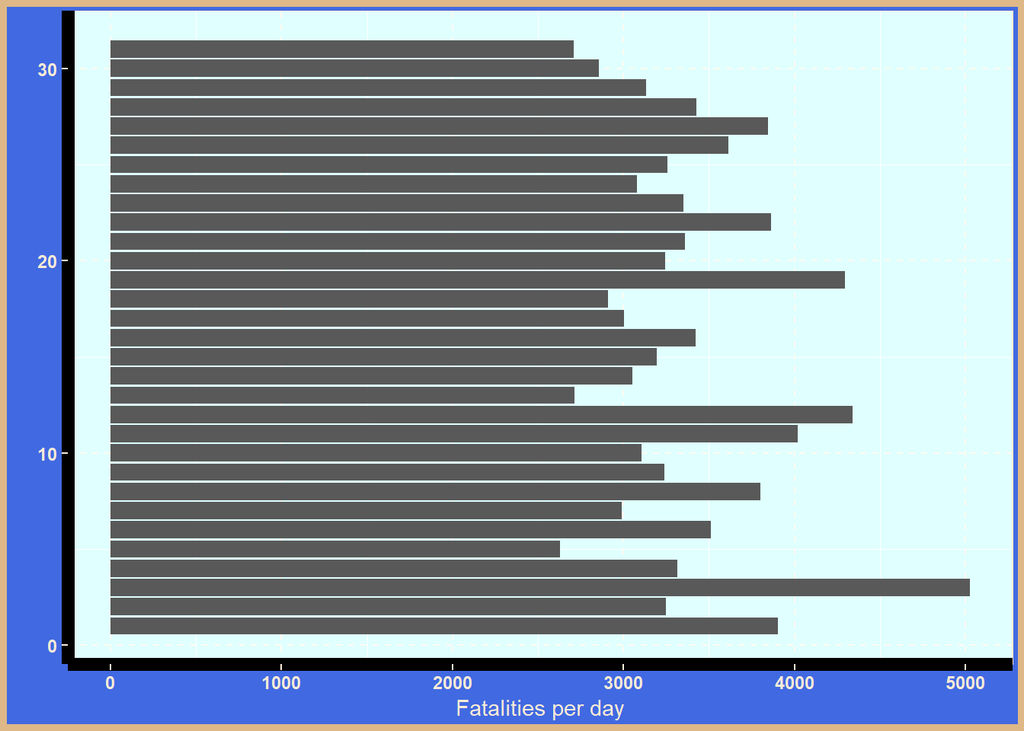

```r
fat_day <- ggplot(plane, aes(Day)) + geom_bar(aes(weight=Fatalities)) + coord_flip() + xlab("") + ylab("Fatalities per day")
fat_day +
  theme(plot.background = element_rect(fill = "royalblue", color = "burlywood", size = 3)) +
  #theme(plot.background = element_rect(fill = "lightgoldenrod")) +
  theme(legend.background = element_rect(fill = "antiquewhite")) +
  theme(legend.position = "right", legend.direction = "vertical") +
  theme(axis.text = element_text(colour = "antiquewhite", face = "bold")) +
  theme(axis.title = element_text(colour = "antiquewhite")) +
  theme(axis.ticks = element_line(colour = "antiquewhite", size = .5)) +
  theme(panel.grid.major = element_line(colour = "floralwhite", linetype = "dashed")) +
  theme(panel.background = element_rect(fill = "lightcyan")) +
  theme(panel.border = element_rect(colour = "antiquewhite", fill = NA)) +
  theme(axis.line = element_line(size = 3, colour = "black")) +
  theme(legend.box.background = element_rect(colour = "floralwhite", size = 2))
```

Each graph shows the amount of fatalities for that given space of time.

Fatalities per month: Not too much to see here, but it is surprising there are not that many deaths in January. There are alot of crashes.

Fatalities per day: Do not fly on the 3rd!

```r
library(rgl)
open3d()
```

```
## wgl
##   1
```

```r
bg3d(color = "lightblue")

d <- plane$Aboard - plane$Fatalities

xyz <- plot3d(plane$Year, plane$Aboard, d, xlab = "Year", ylab = "Aboard", zlab = "Survivors")
aspect3d(1,1,.5)

axes3d(edges = "bbox", labels = F, tick = T, nticks = 5,
       box = F)

abclines3d(0, 400, 100, a = diag(400), col = "darkblue")
```

[output not shown]